# ggplot2

Suraj Bhattarai

December 12, 2018

## ggplot syntax

ggplot(diamonds, aes(x=carat,y=price)) + geom_point()

The basic concept of a ggplot graphic is to combine different elements into *layers*. Each layer of a ggplotgraphic must have a data set and aesthetic mappings

- **data**: for **ggplot()**, this must be a data frame!
- **aes**: a mapping from the data to the plot; basically the x and y-axes

ggplot(diamonds, aes(x=carat,y=price)) + geom_point()

Layers can also have:

- a geom, or a geometric object: defines the overall look of the layer – is it bars, points, or lines?
- a stat, or a statistical summary: how should the data be summarized (e.g., binning for histograms, or smoothing to draw regression lines, etc).
- a position: how to handle overlapping points

When not specified, the defaults are used.

We can use **geom_boxplot** to create boxplots when one variable is continuous and the other is a factor.

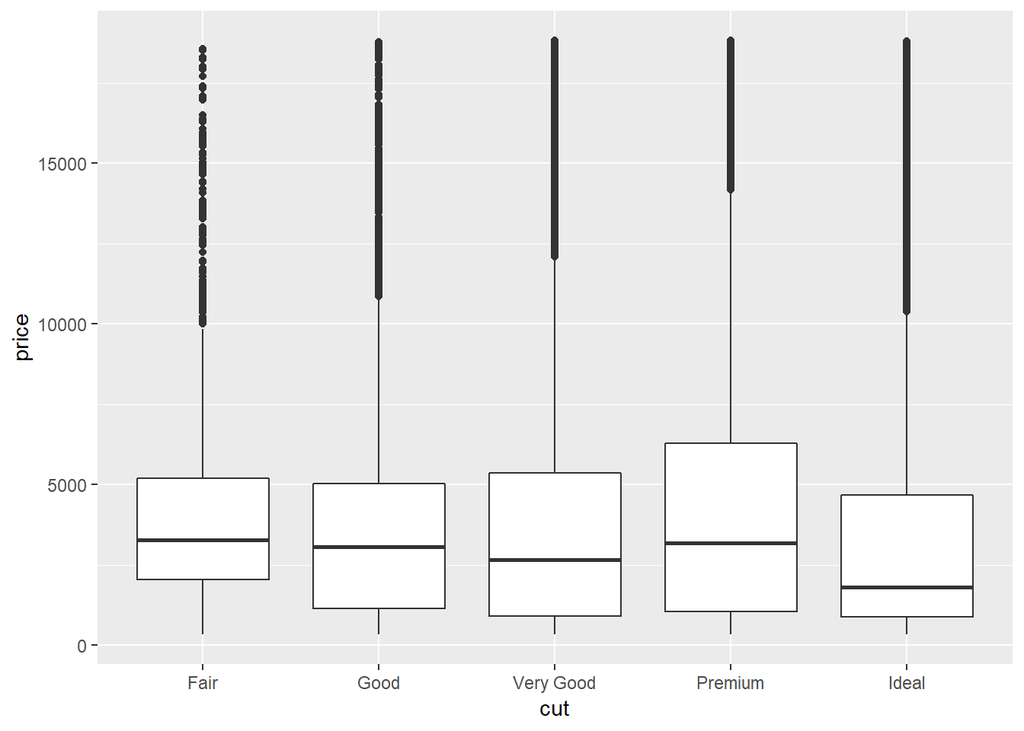

```r
library(ggplot2)
ggplot(diamonds, aes(x=cut,y=price)) + geom_boxplot()
```

We can control the aesthetics of each layer, e.g. *colour*, *size*, *shape*, *alpha* (opacity) etc.

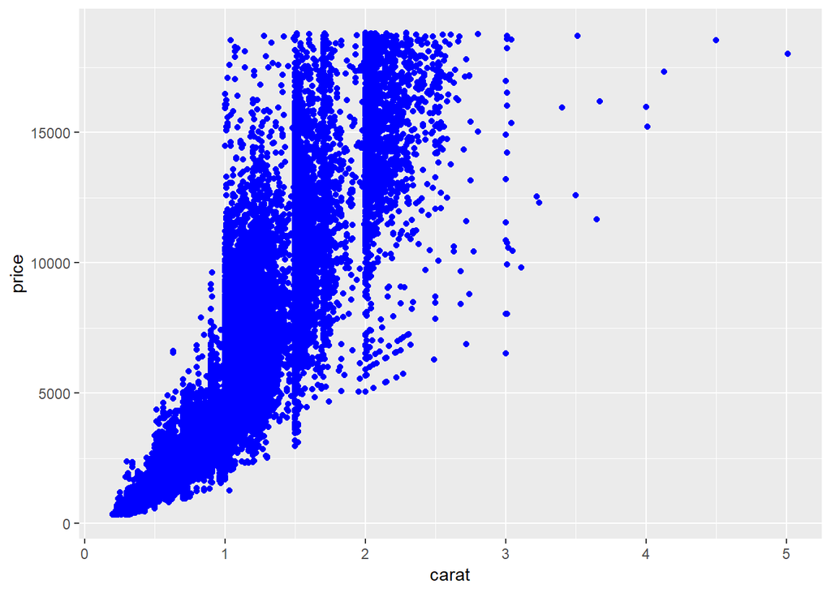

```r
ggplot(diamonds, aes(carat, price)) + geom_point(colour = "blue")
```

Changing the alpha level

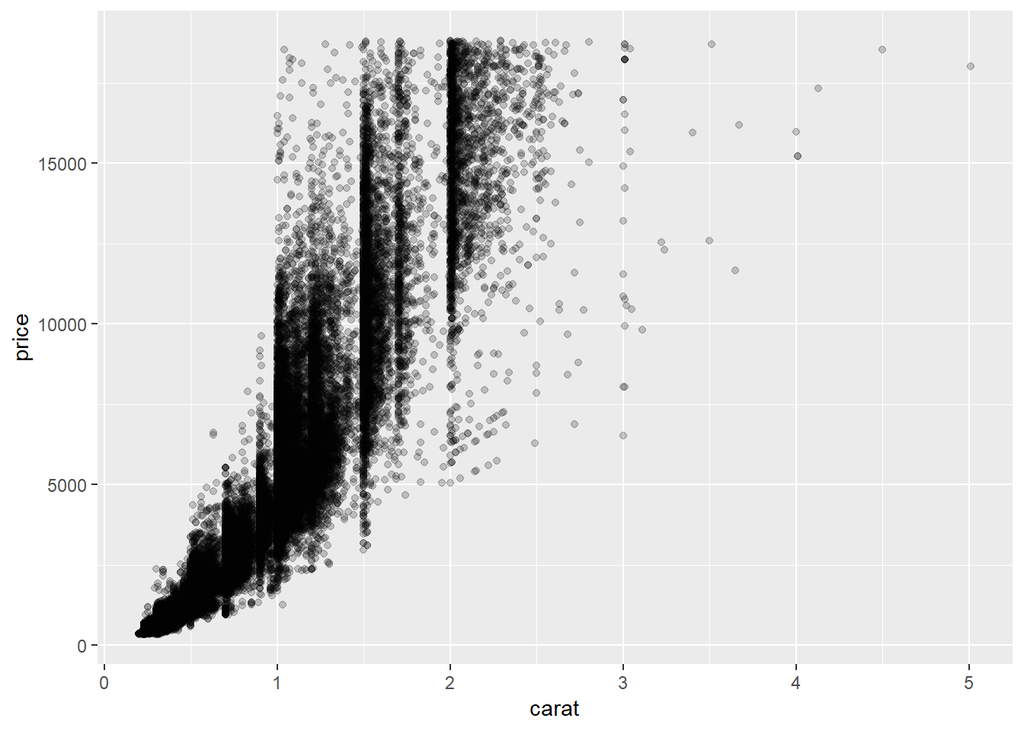

```r
ggplot(diamonds, aes(x=carat,y=price)) + geom_point(alpha = 0.2)
```

Changing the point size

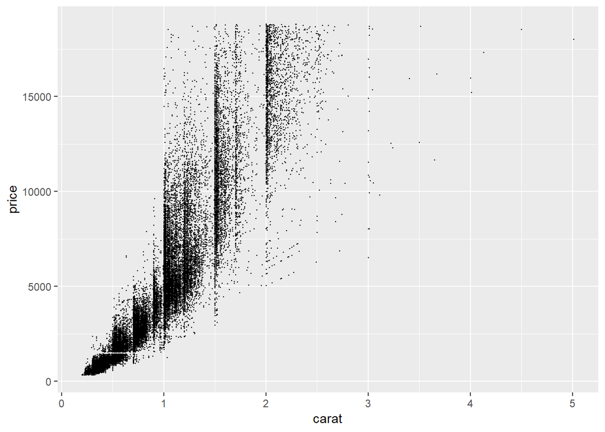

```r
ggplot(diamonds, aes(x=carat,y=price)) + geom_point(size = 0.2)
```

Changing the shape and the point size

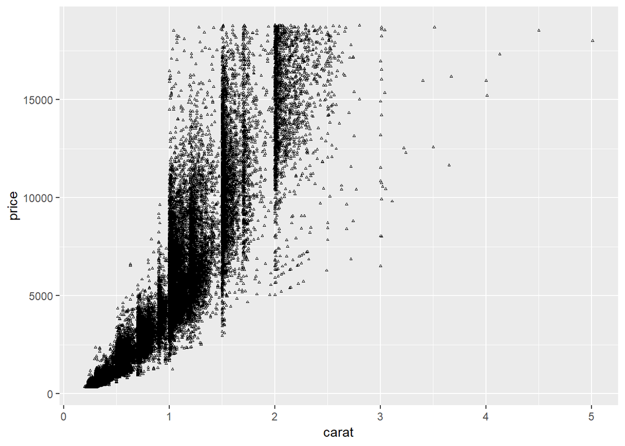

```r
ggplot(diamonds, aes(x=carat,y=price)) + geom_point(shape = 2,size=0.4)
```

The real power of **ggplot** is its ability to combine layers

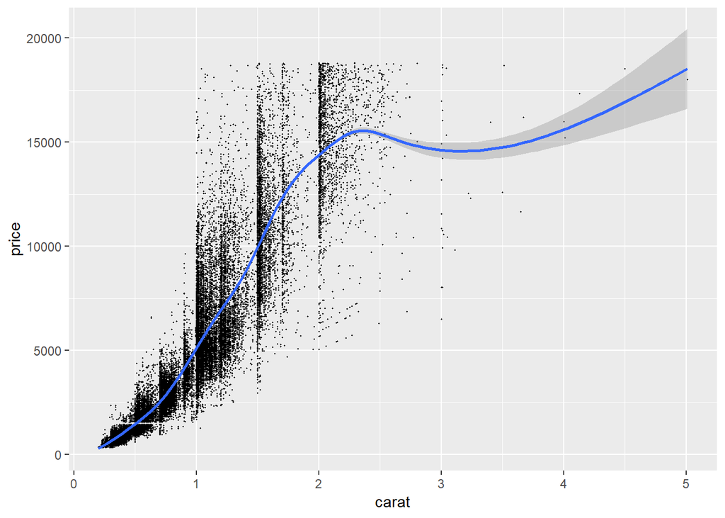

```r
ggplot(diamonds, aes(x=carat,y=price)) + geom_point(size = 0.2) +
  geom_smooth()
```

In some cases, it may be more useful to get separate plots for each category of the third variable, to understand conditional relationships; using a facet wrap

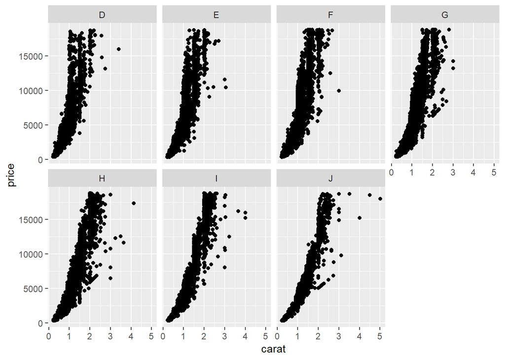

```r
ggplot(diamonds, aes(carat, price)) + geom_point() +
  facet_wrap(~color, ncol=4)
```

Alternatively, you can use **facet_grid**, which also allows more than 1 conditioning variable (tables of plots)

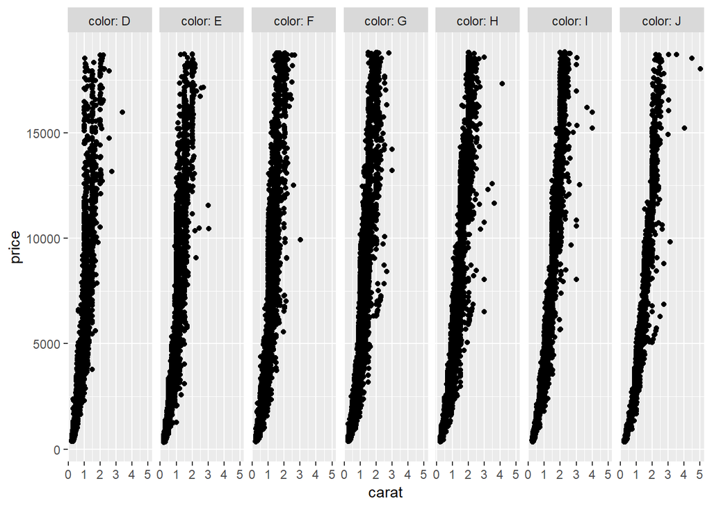

```r
ggplot(diamonds, aes(carat, price)) + geom_point() +
 facet_grid(~color, labeller=label_both)
```

There are actually many ways to get the same plot! The following commands will produce the same plot:

- ggplot(diamonds, aes(price, carat)) + geom_point()
- ggplot() + geom_point(aes(price, carat), diamonds)
- ggplot(diamonds) + geom_point(aes(price, carat))
- ggplot(diamonds, aes(price)) + geom_point(aes(y = carat))
- ggplot(diamonds, aes(y=carat)) + geom_point(aes(x = price))

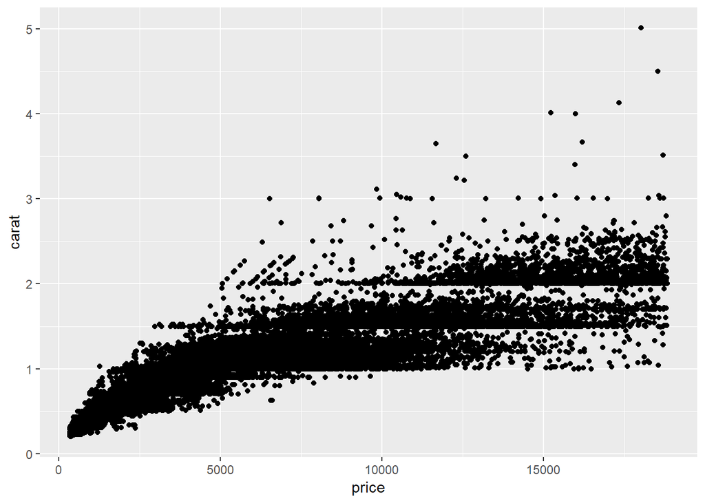

```r
ggplot(diamonds) + geom_point(aes(price, carat))
```

We can summarize univariate distributions using **boxplots**

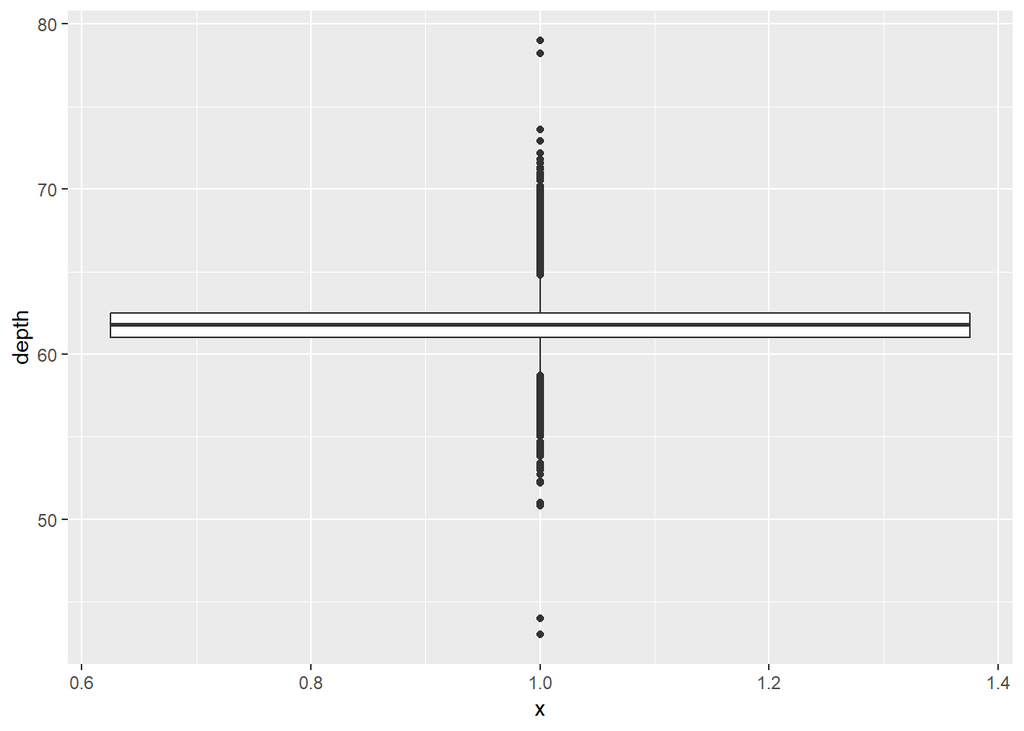

```r
ggplot(diamonds, aes(1, depth)) + geom_boxplot()
```

However, a *histogram* would be a better choice here

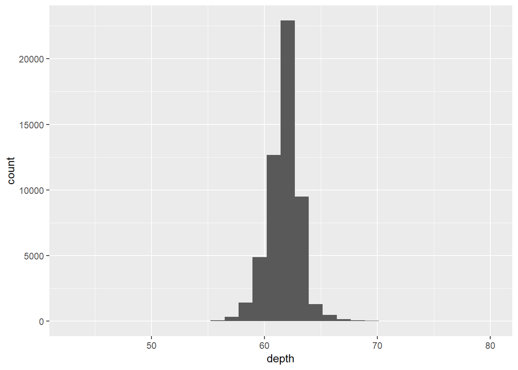

```r
ggplot(diamonds, aes(depth)) + geom_histogram()
```

Notice the difference in the **aes** call; **boxplot** is really designed for multiple categories!

Tthe *default options* in **histogram** may not be sensible, and you often need to adjust the **binwidth** and **xlim**

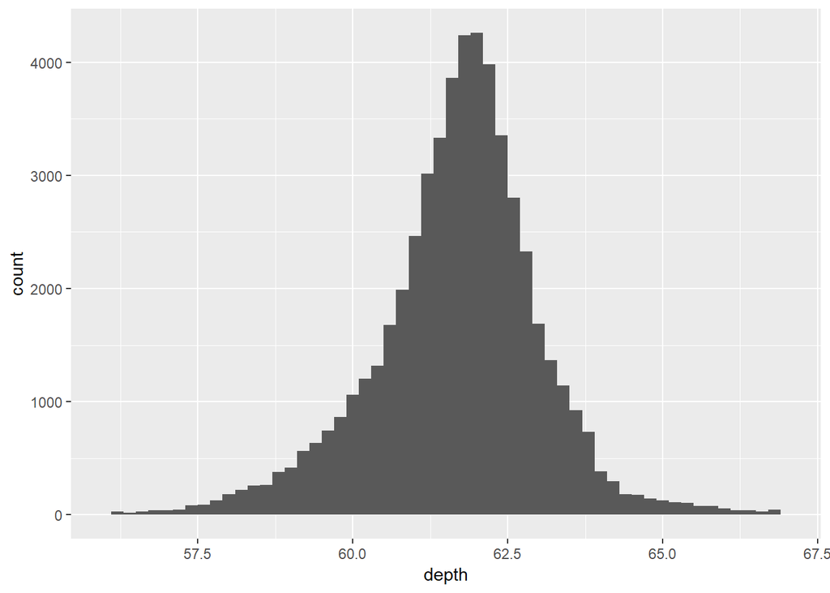

```r
ggplot(diamonds, aes(depth)) + geom_histogram(binwidth=0.2) + xlim(56,67)
```

A better use of **boxplot** is when we want to compare distributions of a quantitative variable across categories of a factor variable, as previously discussed

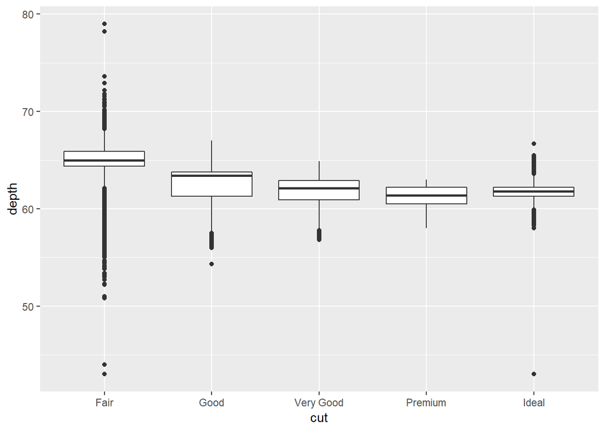

```r
ggplot(diamonds, aes(cut, depth)) + geom_boxplot()
```

We can also get multiple histograms, though we need to either display them separately (less useful when comparing)

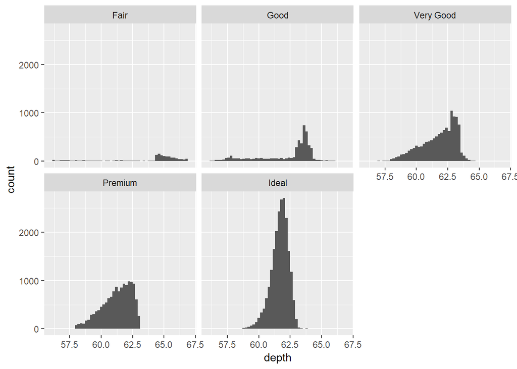

```r
ggplot(diamonds, aes(depth)) + geom_histogram(binwidth = 0.2) +
    facet_wrap(~cut) + xlim(56, 67)
```

Or, we can overlay the historgrams

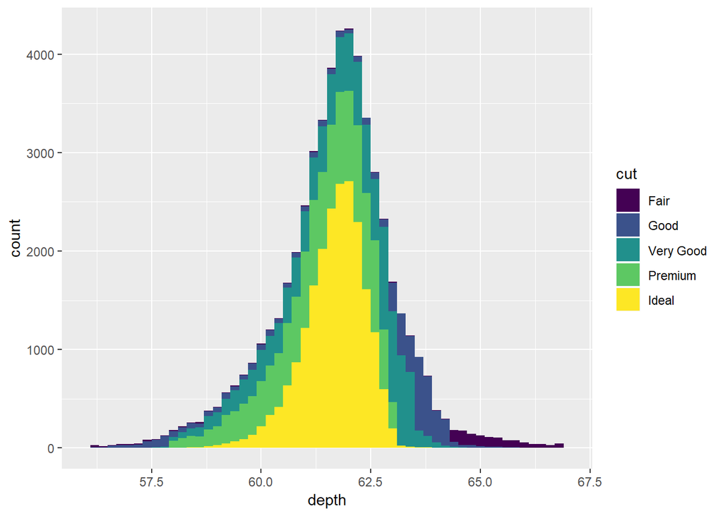

```r
ggplot(diamonds, aes(depth, fill=cut)) +
    geom_histogram(binwidth=0.2) + xlim(56,67)
```